# INNHotels

Importing necessary libraries

```python
#Importing Data manupulation libraries
import pandas as pd
import numpy as np

#Importing Data visualisation libraries
import matplotlib.pyplot as plt
import seaborn as sns

#library to split dataset to training and testing data
from sklearn.model_selection import train_test_split

#library for hyperParameter Tuning
from sklearn.model_selection import GridSearchCV

#Importing necessary libraries for Decision Tree Classifiers
from sklearn import tree
from sklearn.tree import DecisionTreeClassifier

#libraries for metrics evaluation
from sklearn.metrics import confusion_matrix,classification_report,accuracy_score,roc_curve,auc
```

Loading the dataset

```python
df=pd.read_csv("INNHotelsGroup.csv")
df.head()
```

|  | Booking_ID | no_of_adults | no_of_children | no_of_weekend_nights | no_of_week_nights | type_of_meal_plan | required_car_parking_space | room_type_reserved | lead_time | arrival_year | arrival_month | arrival_date | market_segment_type | repeated_guest | no_of_previous_cancellations | no_of_previous_bookings_not_canceled | avg_price_per_room | no_of_special_requests | booking_status |
| --- | --- | --- | --- | --- | --- | --- | --- | --- | --- | --- | --- | --- | --- | --- | --- | --- | --- | --- | --- |
| 0 | INN00001 | 2 | 0 | 1 | 2 | Meal Plan 1 | 0 | Room_Type 1 | 224 | 2017 | 10 | 2 | Offline | 0 | 0 | 0 | 65.00 | 0 | Not_Canceled |
| 1 | INN00002 | 2 | 0 | 2 | 3 | Not Selected | 0 | Room_Type 1 | 5 | 2018 | 11 | 6 | Online | 0 | 0 | 0 | 106.68 | 1 | Not_Canceled |
| 2 | INN00003 | 1 | 0 | 2 | 1 | Meal Plan 1 | 0 | Room_Type 1 | 1 | 2018 | 2 | 28 | Online | 0 | 0 | 0 | 60.00 | 0 | Canceled |
| 3 | INN00004 | 2 | 0 | 0 | 2 | Meal Plan 1 | 0 | Room_Type 1 | 211 | 2018 | 5 | 20 | Online | 0 | 0 | 0 | 100.00 | 0 | Canceled |
| 4 | INN00005 | 2 | 0 | 1 | 1 | Not Selected | 0 | Room_Type 1 | 48 | 2018 | 4 | 11 | Online | 0 | 0 | 0 | 94.50 | 0 | Canceled |

Data Overview

```python
df.info()
```

```
<class 'pandas.core.frame.DataFrame'>
RangeIndex: 36275 entries, 0 to 36274
Data columns (total 19 columns):
 #   Column                                Non-Null Count  Dtype
---  ------                                --------------  -----
 0   Booking_ID                            36275 non-null  object
 1   no_of_adults                          36275 non-null  int64
 2   no_of_children                        36275 non-null  int64
 3   no_of_weekend_nights                  36275 non-null  int64
 4   no_of_week_nights                     36275 non-null  int64
 5   type_of_meal_plan                     36275 non-null  object
 6   required_car_parking_space            36275 non-null  int64
 7   room_type_reserved                    36275 non-null  object
 8   lead_time                             36275 non-null  int64
 9   arrival_year                          36275 non-null  int64
 10  arrival_month                         36275 non-null  int64
 11  arrival_date                          36275 non-null  int64
 12  market_segment_type                   36275 non-null  object
 13  repeated_guest                        36275 non-null  int64
 14  no_of_previous_cancellations          36275 non-null  int64
 15  no_of_previous_bookings_not_canceled  36275 non-null  int64
 16  avg_price_per_room                    36275 non-null  float64
 17  no_of_special_requests                36275 non-null  int64
 18  booking_status                        36275 non-null  object
dtypes: float64(1), int64(13), object(5)
memory usage: 5.3+ MB
```

```python
df.describe().T
```

|  | count | mean | std | min | 25% | 50% | 75% | max |
| --- | --- | --- | --- | --- | --- | --- | --- | --- |
| no_of_adults | 36275.0 | 1.844962 | 0.518715 | 0.0 | 2.0 | 2.00 | 2.0 | 4.0 |
| no_of_children | 36275.0 | 0.105279 | 0.402648 | 0.0 | 0.0 | 0.00 | 0.0 | 10.0 |
| no_of_weekend_nights | 36275.0 | 0.810724 | 0.870644 | 0.0 | 0.0 | 1.00 | 2.0 | 7.0 |
| no_of_week_nights | 36275.0 | 2.204300 | 1.410905 | 0.0 | 1.0 | 2.00 | 3.0 | 17.0 |
| required_car_parking_space | 36275.0 | 0.030986 | 0.173281 | 0.0 | 0.0 | 0.00 | 0.0 | 1.0 |
| lead_time | 36275.0 | 85.232557 | 85.930817 | 0.0 | 17.0 | 57.00 | 126.0 | 443.0 |
| arrival_year | 36275.0 | 2017.820427 | 0.383836 | 2017.0 | 2018.0 | 2018.00 | 2018.0 | 2018.0 |
| arrival_month | 36275.0 | 7.423653 | 3.069894 | 1.0 | 5.0 | 8.00 | 10.0 | 12.0 |
| arrival_date | 36275.0 | 15.596995 | 8.740447 | 1.0 | 8.0 | 16.00 | 23.0 | 31.0 |
| repeated_guest | 36275.0 | 0.025637 | 0.158053 | 0.0 | 0.0 | 0.00 | 0.0 | 1.0 |
| no_of_previous_cancellations | 36275.0 | 0.023349 | 0.368331 | 0.0 | 0.0 | 0.00 | 0.0 | 13.0 |
| no_of_previous_bookings_not_canceled | 36275.0 | 0.153411 | 1.754171 | 0.0 | 0.0 | 0.00 | 0.0 | 58.0 |
| avg_price_per_room | 36275.0 | 103.423539 | 35.089424 | 0.0 | 80.3 | 99.45 | 120.0 | 540.0 |
| no_of_special_requests | 36275.0 | 0.619655 | 0.786236 | 0.0 | 0.0 | 0.00 | 1.0 | 5.0 |

observations: .The average no_of_adults is 1.8,implies that majority of bookings have 1 or 2 adults and maximum is 4. .In majority of the bookings children are not accompanied by adults as avg is approx 0.1 though the maximum number of children in a bokking are 10. .The average bookings for number of weekend nights is 0.8,implying that majority of guests stay often shorter periods over weekend. .The average number of week nights guests stay is around 2.2,implying that guests prefer to stay on week nights rather than weekend nights.The maximum number of week nights is 17,some guests have longer stay. .The majority of bookings didnt require for car parking space. .The average lead time is 85,implying that mjority guests booked in advance of 85 days,though some guests made bookings in year advance(443 days) .The majority of bookings in the dataset were made in the year 2018. .Only a small percentage of guests are repeated guests. .Number of previous cancellation has also been small,the maximum cancellations of the bookings in this dataset is 13. .The average price of the room is 103 Euros.The minimum price is 0 implying that there could be any special offering or free stays.The maxiumum is 540 Euros for the some luxury rooms. .On average, guests make approximately 0.6 special requests per booking, while the maximum is 5.

```python
df.describe(include=['object']).T
```

|  | count | unique | top | freq |
| --- | --- | --- | --- | --- |
| Booking_ID | 36275 | 36275 | INN36275 | 1 |
| type_of_meal_plan | 36275 | 4 | Meal Plan 1 | 27835 |
| room_type_reserved | 36275 | 7 | Room_Type 1 | 28130 |
| market_segment_type | 36275 | 5 | Online | 23214 |
| booking_status | 36275 | 2 | Not_Canceled | 24390 |

observations: .The booking_id is unique value. .Most guests opted for Meal plan 1. .Most guests reserved Room type 1.

Exploratory Data Analysis

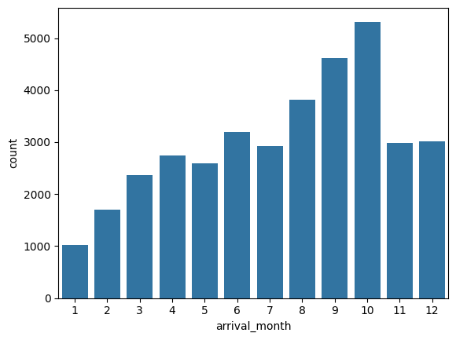

```
arrival_month
10    5317
9     4611
8     3813
6     3203
12    3021
11    2980
7     2920
4     2736
5     2598
3     2358
2     1704
1     1014
Name: count, dtype: int64
```

```python
sns.countplot(x='arrival_month',data=df)
plt.show()
df['arrival_month'].value_counts()
```

Observation:The number of bookings,5317, in 10 month(october)is highest.

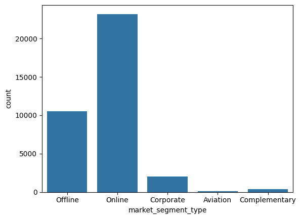

```
market_segment_type
Online           23214
Offline          10528
Corporate         2017
Complementary      391
Aviation           125
Name: count, dtype: int64
```

```python
sns.countplot(x='market_segment_type',data=df)
plt.show()
df['market_segment_type'].value_counts()
```

observations:Most of the guest come from market segment type-online around 23214,followed by offline

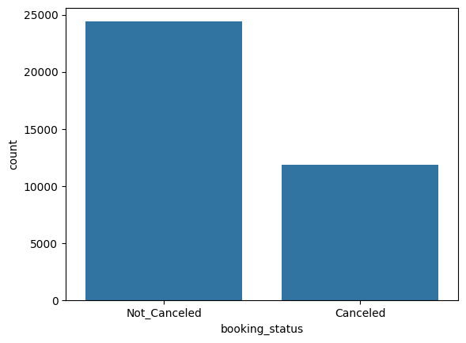

```
booking_status
Not_Canceled    67.236389
Canceled        32.763611
Name: proportion, dtype: float64
```

```python
sns.countplot(x='booking_status',data=df)
plt.show()

df['booking_status'].value_counts(normalize=True)*100
```

observations:approx 32% of bookings are cancelled.

```python
# Get the canceled bookings for repeated guests (True)
cancelled_bookings = df[df['booking_status'] == 'Canceled'].groupby(df['repeated_guest'] == 1).size()

# Total count of repeated guests (True)
total_repeated_guests = df[df['repeated_guest'] == 1].groupby('repeated_guest').size()

# Calculate percentage
percentage_canceled = (cancelled_bookings / total_repeated_guests) * 100

# Filter out NaN and only get the value for True repeated guests
percentage_canceled = percentage_canceled[True]

# Print the result
print(percentage_canceled)
```

```
1.7204301075268817
```

observations:1.72% of repeated guests cancelled bookings

```python
df[df['no_of_special_requests']>0].groupby('booking_status').size()
```

```
booking_status
Canceled         3340
Not_Canceled    13158
dtype: int64
```

```python
df.groupby(['no_of_special_requests','booking_status']).size().groupby(level=0).apply(lambda x: x / x.sum() * 100)
```

```
no_of_special_requests  no_of_special_requests  booking_status
0                       0                       Canceled           43.206755
                                                Not_Canceled       56.793245
1                       1                       Canceled           23.766816
                                                Not_Canceled       76.233184
2                       2                       Canceled           14.596700
                                                Not_Canceled       85.403300
3                       3                       Not_Canceled      100.000000
4                       4                       Not_Canceled      100.000000
5                       5                       Not_Canceled      100.000000
dtype: float64
```

observations: .The number of bookings cancelled were high when no special requests are made. .The number of bookings cancelled significantly when requests are made,it decreased to 23% when only 1 request is made and reduced to 14% when 2 requests are made. .There were no cancellations when the number of request are above 2

```python
df.groupby('market_segment_type')['avg_price_per_room'].mean().sort_values(ascending=False)
```

```
market_segment_type
Online           112.256855
Aviation         100.704000
Offline           91.632679
Corporate         82.911740
Complementary      3.141765
Name: avg_price_per_room, dtype: float64
```

Observations:The online market segment has the highest avg price,followed by Aviation,offline The Complementary has lowest average price per room

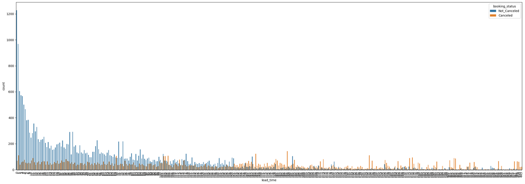

```python
# how does lead time effect cancellation
plt.figure(figsize=(30,10))
sns.countplot(x='lead_time',data=df,hue='booking_status')
plt.xticks(rotation=90)
plt.show()
```

observation:the booking cancellation is spread through the lead time,but the proportion of bookings cancelled is greater when the lead time increased

```
no_of_weekend_nights
0    5093
1    3432
2    3157
3      74
4      83
5      29
6      16
7       1
dtype: int64 no_of_week_nights
0      679
1     2572
2     3997
3     2574
4     1143
5      632
6       88
7       52
8       32
9       21
10      53
11      14
12       7
13       5
14       4
15       8
16       2
17       2
dtype: int64
```

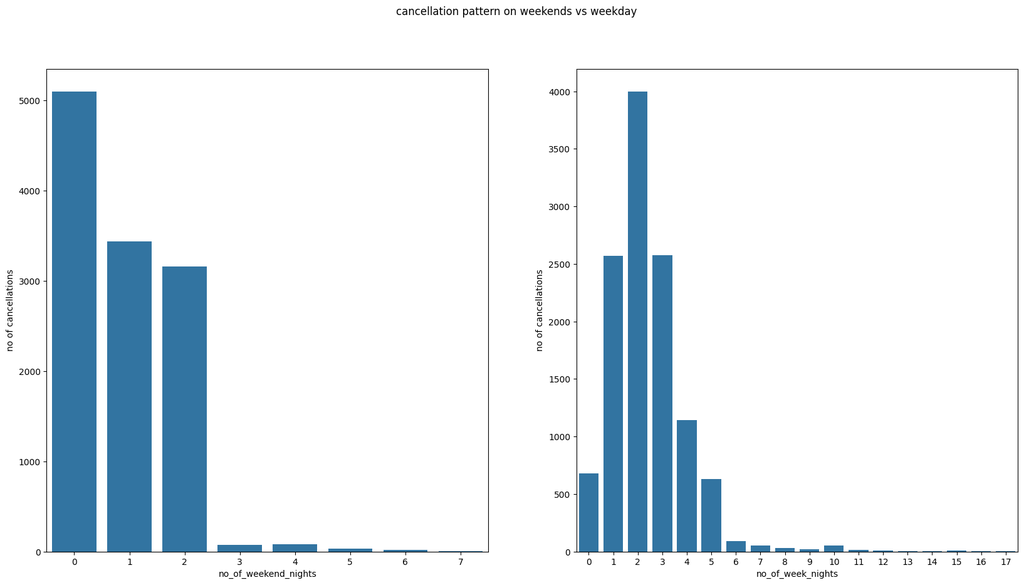

```python
#do weekends v weekday have differnt patterns on cancelation?
a=df[df['booking_status']=='Canceled'].groupby('no_of_weekend_nights').size()
b=df[df['booking_status']=='Canceled'].groupby(['no_of_week_nights']).size()
print(a,b)
plt.figure(figsize=(20,10))
plt.subplot(1,2,1)
plt.ylabel("no of cancellations")
plt.suptitle("cancellation pattern on weekends vs weekday")
sns.barplot(data=a)
plt.subplot(1,2,2)
plt.ylabel("no of cancellations")
sns.barplot(data=b)
plt.show()
```

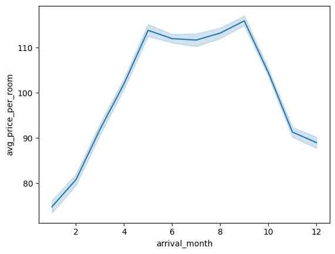

```python
sns.lineplot(data=df,x='arrival_month',y='avg_price_per_room')
plt.show()
```

observations: .The prices are lower in the initial months and increased gradually. .The prices of rooms are higher in months between May to September and then decreased during end of year.

Univariate Analysis

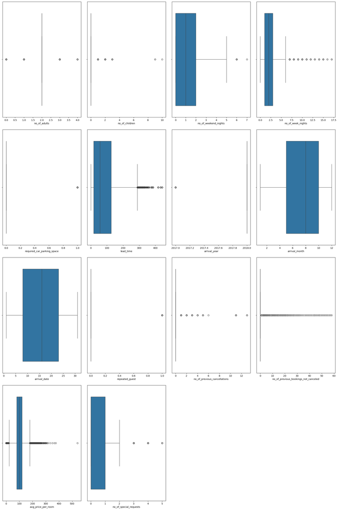

```python
plt.figure(figsize=(20,30))
nums_cols=df.select_dtypes(include=np.number).columns.tolist()
for i,var in enumerate(nums_cols):
    plt.subplot(4,4,i+1)
    sns.boxplot(data=df,x=var)
    plt.tight_layout(pad=2)
plt.show()
```

observations:There are many outliers in lead_time,previous bookings not cancelled,avg price of room.But these are necessary to predict our target variable,so we are not treating outliers

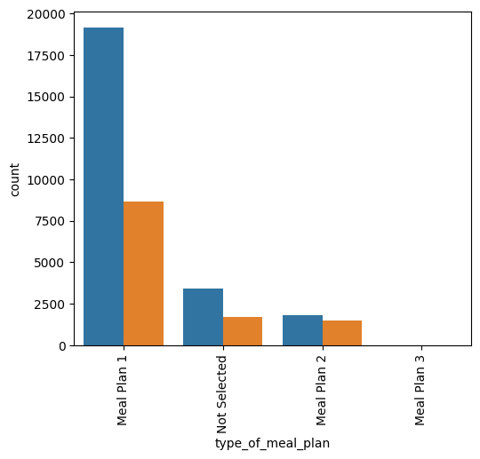

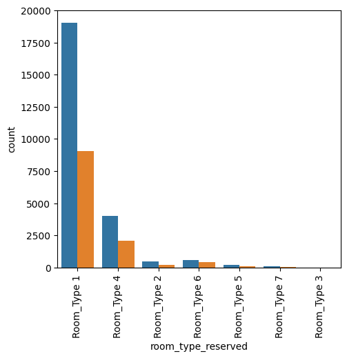

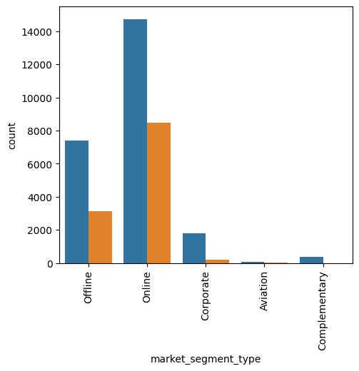

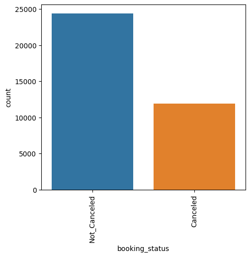

```python
df1=df.copy()
df1.drop('Booking_ID',axis=1,inplace=True)
cat_cols=df1.select_dtypes(include=['object','category']).columns.tolist()
for i,var in enumerate(cat_cols):
    plt.figure(figsize=(20,20))
    plt.subplot(4,4,i+1)
    sns.countplot(data=df1,x=var,hue='booking_status')
    plt.legend().set_visible(False)  # Hide the legend

    plt.xticks(rotation=90)
    plt.tight_layout(pad=2)
plt.show()
```

observations:room type and market segment are good predictors for target variable y

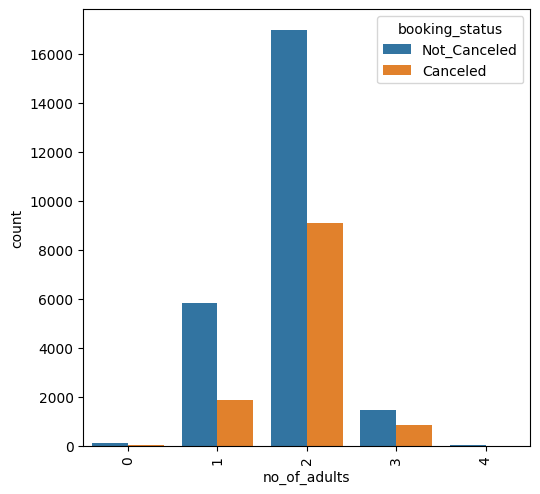

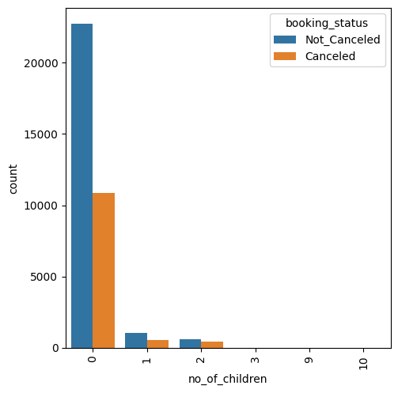

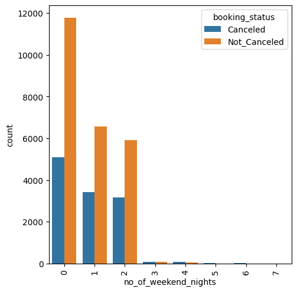

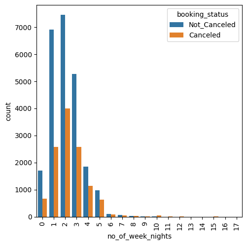

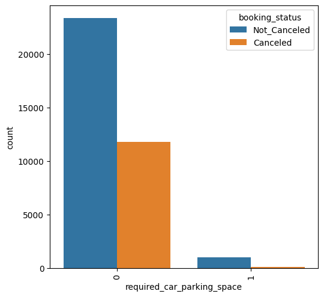

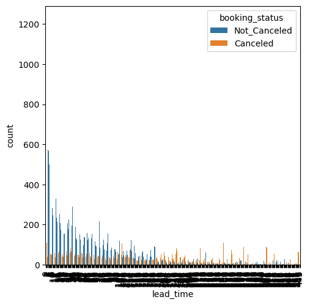

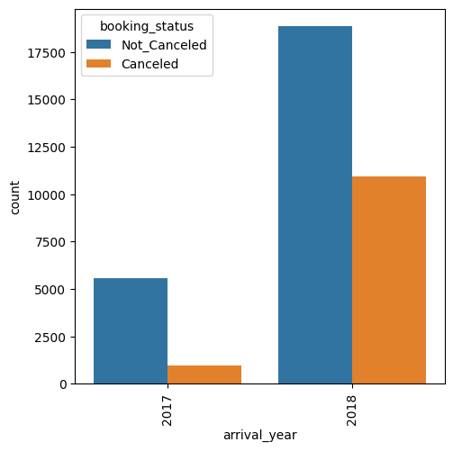

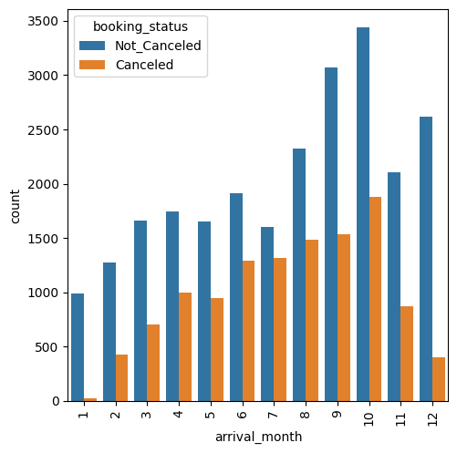

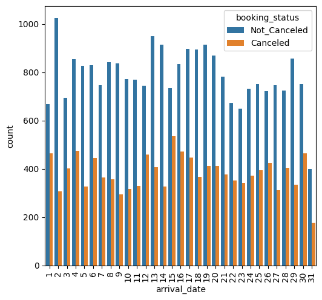

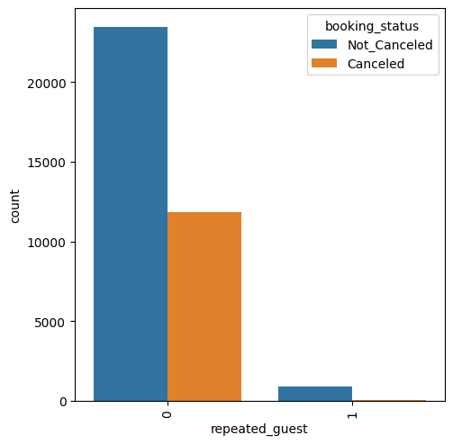

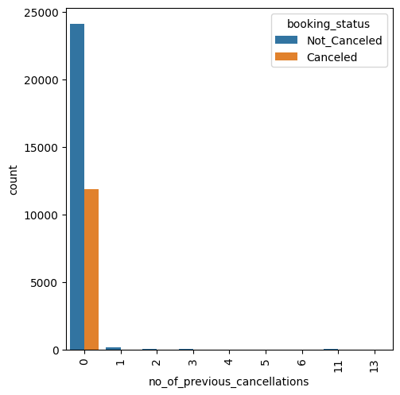

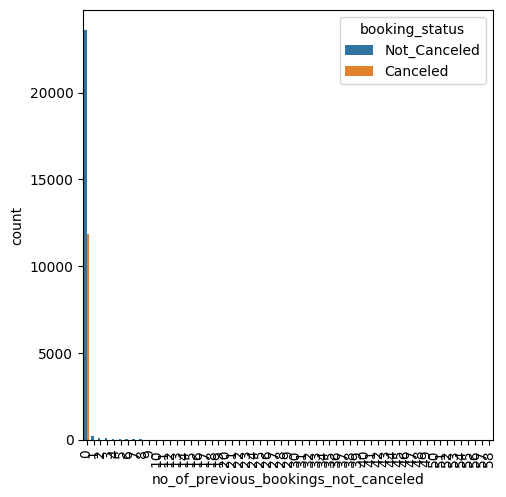

[2 more figures not shown]

```python
nums_col=df.select_dtypes(include=np.number).columns.tolist()
for i,var in enumerate(nums_col):
    plt.figure(figsize=(20,20))
    plt.subplot(4,4,i+1)
    sns.countplot(data=df,x=var,hue='booking_status')
    plt.xticks(rotation=90)
    plt.tight_layout(pad=2)
plt.show()
```

Observations: from above plots,no of special requests,avg price per room,arrival month,lead time,no of weeks nights,no of adults ae good predictors for our target variable

Bivariate Analysis

```python
df2=df1.copy()
df2['booking_status']=df2['booking_status'].map({'Not_Canceled':0,'Canceled':1})
```

```python
df3=df2.drop(df2.select_dtypes(include=['object']).columns.tolist(),axis=1)
```

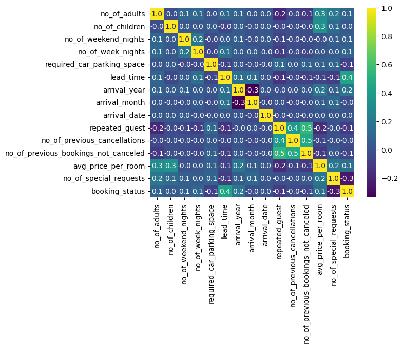

```python
sns.heatmap(df3.corr(),annot=True,fmt=".1f",cmap='viridis')
plt.show()
```

Data processing

```python
df1=df.copy()
#checking for null values
df.isnull().sum()
```

```
Booking_ID                              0
no_of_adults                            0
no_of_children                          0
no_of_weekend_nights                    0
no_of_week_nights                       0
type_of_meal_plan                       0
required_car_parking_space              0
room_type_reserved                      0
lead_time                               0
arrival_year                            0
arrival_month                           0
arrival_date                            0
market_segment_type                     0
repeated_guest                          0
no_of_previous_cancellations            0
no_of_previous_bookings_not_canceled    0
avg_price_per_room                      0
no_of_special_requests                  0
booking_status                          0
dtype: int64
```

observation:No null values are detected

```python
#checking is data is duplicated
df.duplicated().sum()
```

```
np.int64(0)
```

observation:no duplicate data found

```python
#removing Booking Id column,as it is contains only unique id.
df.drop('Booking_ID',axis=1,inplace=True)
```

```python
#converting target variable to numerical data by mapping
df['booking_status']=df['booking_status'].map({'Not_Canceled':0,'Canceled':1})
df.head()
```

|  | no_of_adults | no_of_children | no_of_weekend_nights | no_of_week_nights | type_of_meal_plan | required_car_parking_space | room_type_reserved | lead_time | arrival_year | arrival_month | arrival_date | market_segment_type | repeated_guest | no_of_previous_cancellations | no_of_previous_bookings_not_canceled | avg_price_per_room | no_of_special_requests | booking_status |
| --- | --- | --- | --- | --- | --- | --- | --- | --- | --- | --- | --- | --- | --- | --- | --- | --- | --- | --- |
| 0 | 2 | 0 | 1 | 2 | Meal Plan 1 | 0 | Room_Type 1 | 224 | 2017 | 10 | 2 | Offline | 0 | 0 | 0 | 65.00 | 0 | 0 |
| 1 | 2 | 0 | 2 | 3 | Not Selected | 0 | Room_Type 1 | 5 | 2018 | 11 | 6 | Online | 0 | 0 | 0 | 106.68 | 1 | 0 |
| 2 | 1 | 0 | 2 | 1 | Meal Plan 1 | 0 | Room_Type 1 | 1 | 2018 | 2 | 28 | Online | 0 | 0 | 0 | 60.00 | 0 | 1 |
| 3 | 2 | 0 | 0 | 2 | Meal Plan 1 | 0 | Room_Type 1 | 211 | 2018 | 5 | 20 | Online | 0 | 0 | 0 | 100.00 | 0 | 1 |
| 4 | 2 | 0 | 1 | 1 | Not Selected | 0 | Room_Type 1 | 48 | 2018 | 4 | 11 | Online | 0 | 0 | 0 | 94.50 | 0 | 1 |

```python
#converting categorical data to numerical data
df=pd.get_dummies(df,columns=df.select_dtypes(include=['object','category']).columns.tolist(),drop_first=True)
df.head()
```

|  | no_of_adults | no_of_children | no_of_weekend_nights | no_of_week_nights | required_car_parking_space | lead_time | arrival_year | arrival_month | arrival_date | repeated_guest | ... | room_type_reserved_Room_Type 2 | room_type_reserved_Room_Type 3 | room_type_reserved_Room_Type 4 | room_type_reserved_Room_Type 5 | room_type_reserved_Room_Type 6 | room_type_reserved_Room_Type 7 | market_segment_type_Complementary | market_segment_type_Corporate | market_segment_type_Offline | market_segment_type_Online |
| --- | --- | --- | --- | --- | --- | --- | --- | --- | --- | --- | --- | --- | --- | --- | --- | --- | --- | --- | --- | --- | --- |
| 0 | 2 | 0 | 1 | 2 | 0 | 224 | 2017 | 10 | 2 | 0 | ... | False | False | False | False | False | False | False | False | True | False |
| 1 | 2 | 0 | 2 | 3 | 0 | 5 | 2018 | 11 | 6 | 0 | ... | False | False | False | False | False | False | False | False | False | True |
| 2 | 1 | 0 | 2 | 1 | 0 | 1 | 2018 | 2 | 28 | 0 | ... | False | False | False | False | False | False | False | False | False | True |
| 3 | 2 | 0 | 0 | 2 | 0 | 211 | 2018 | 5 | 20 | 0 | ... | False | False | False | False | False | False | False | False | False | True |
| 4 | 2 | 0 | 1 | 1 | 0 | 48 | 2018 | 4 | 11 | 0 | ... | False | False | False | False | False | False | False | False | False | True |

5 rows × 28 columns

```python
#explicitly converting Bool data to numerical data by mapping
bool_cols=df.select_dtypes(include='bool').columns.tolist()
for col in bool_cols:
    df[col]=df[col].map({False:0,True:1})
df.head()
```

|  | no_of_adults | no_of_children | no_of_weekend_nights | no_of_week_nights | required_car_parking_space | lead_time | arrival_year | arrival_month | arrival_date | repeated_guest | ... | room_type_reserved_Room_Type 2 | room_type_reserved_Room_Type 3 | room_type_reserved_Room_Type 4 | room_type_reserved_Room_Type 5 | room_type_reserved_Room_Type 6 | room_type_reserved_Room_Type 7 | market_segment_type_Complementary | market_segment_type_Corporate | market_segment_type_Offline | market_segment_type_Online |
| --- | --- | --- | --- | --- | --- | --- | --- | --- | --- | --- | --- | --- | --- | --- | --- | --- | --- | --- | --- | --- | --- |
| 0 | 2 | 0 | 1 | 2 | 0 | 224 | 2017 | 10 | 2 | 0 | ... | 0 | 0 | 0 | 0 | 0 | 0 | 0 | 0 | 1 | 0 |
| 1 | 2 | 0 | 2 | 3 | 0 | 5 | 2018 | 11 | 6 | 0 | ... | 0 | 0 | 0 | 0 | 0 | 0 | 0 | 0 | 0 | 1 |
| 2 | 1 | 0 | 2 | 1 | 0 | 1 | 2018 | 2 | 28 | 0 | ... | 0 | 0 | 0 | 0 | 0 | 0 | 0 | 0 | 0 | 1 |
| 3 | 2 | 0 | 0 | 2 | 0 | 211 | 2018 | 5 | 20 | 0 | ... | 0 | 0 | 0 | 0 | 0 | 0 | 0 | 0 | 0 | 1 |
| 4 | 2 | 0 | 1 | 1 | 0 | 48 | 2018 | 4 | 11 | 0 | ... | 0 | 0 | 0 | 0 | 0 | 0 | 0 | 0 | 0 | 1 |

5 rows × 28 columns

```python
#spliiting the data into test and training data set
X=df.drop('booking_status',axis=1)
y=df['booking_status']
X_train,X_test,y_train,y_test=train_test_split(X,y,test_size=0.3,random_state=42)
print("no of rows in training set",X_train.shape[0])
print("no of rows in testing set",X_test.shape[0])
```

```
no of rows in training set 25392
no of rows in testing set 10883
```

```python
#both classses are balanced,as it contains enough examples for label 0 or 1 for target variable
y_train.value_counts(normalize=True)*100
```

```
booking_status
0    67.399181
1    32.600819
Name: proportion, dtype: float64
```

```python
#normalising the data as the lead ranges from 0 to 443, avg price of room ranges from 0 t0 540
col=['lead_time','avg_price_per_room']
from sklearn.preprocessing import StandardScaler
scaler=StandardScaler()
X_train[col]=scaler.fit_transform(X_train[col])
X_test[col]=scaler.transform(X_test[col])
X_train.head()
```

|  | no_of_adults | no_of_children | no_of_weekend_nights | no_of_week_nights | required_car_parking_space | lead_time | arrival_year | arrival_month | arrival_date | repeated_guest | ... | room_type_reserved_Room_Type 2 | room_type_reserved_Room_Type 3 | room_type_reserved_Room_Type 4 | room_type_reserved_Room_Type 5 | room_type_reserved_Room_Type 6 | room_type_reserved_Room_Type 7 | market_segment_type_Complementary | market_segment_type_Corporate | market_segment_type_Offline | market_segment_type_Online |
| --- | --- | --- | --- | --- | --- | --- | --- | --- | --- | --- | --- | --- | --- | --- | --- | --- | --- | --- | --- | --- | --- |
| 29580 | 2 | 0 | 1 | 3 | 0 | 1.336399 | 2018 | 8 | 29 | 0 | ... | 0 | 0 | 0 | 0 | 0 | 0 | 0 | 0 | 0 | 1 |
| 6325 | 2 | 0 | 1 | 3 | 0 | -0.074775 | 2018 | 3 | 24 | 0 | ... | 0 | 0 | 0 | 0 | 0 | 0 | 0 | 0 | 0 | 1 |
| 33899 | 2 | 0 | 1 | 4 | 0 | -0.086437 | 2018 | 4 | 6 | 0 | ... | 0 | 0 | 1 | 0 | 0 | 0 | 0 | 0 | 0 | 1 |
| 720 | 2 | 0 | 2 | 0 | 0 | -0.284701 | 2017 | 10 | 4 | 0 | ... | 0 | 0 | 0 | 0 | 0 | 0 | 0 | 0 | 1 | 0 |
| 22120 | 2 | 1 | 0 | 4 | 0 | 1.348061 | 2018 | 11 | 1 | 0 | ... | 0 | 0 | 0 | 0 | 0 | 0 | 0 | 0 | 0 | 1 |

5 rows × 27 columns

```python
#deleting arrival year,as it seems to be insignificant feature(year)
df.drop('arrival_year',axis=1,inplace=True)
```

Building Decision Tree Model

```python
#fitting the data using default 'gini' criteria.
from sklearn.tree import DecisionTreeClassifier
model=DecisionTreeClassifier(random_state=42)
model.fit(X_train,y_train)
```

```
DecisionTreeClassifier(random_state=42)
```

```python
#creating a function for metrics evaluation from predicted values
from sklearn.metrics import accuracy_score,recall_score,precision_score,f1_score,confusion_matrix,classification_report
def metrics_evaluation(model,predictors,target):
    #predicting values of  data
    y_pred=model.predict(predictors)
    #evaluating metrics
    acc=accuracy_score(target,y_pred)
    rec=recall_score(target,y_pred)
    f1=f1_score(target,y_pred)
    pre=precision_score(target,y_pred)
    metric_df=pd.DataFrame(
        {'accuracy':acc,'recall':rec,'f1_Score':f1,'precision':pre},
        index=[0])
    return metric_df
```

```python
#creating a function for confusion matrix
def confusion_mat(model,predictors,target):
    y_pred=model.predict(predictors)
    cm=confusion_matrix(target,y_pred)
    labels = np.asarray(
        [
            ["{0:0.0f}".format(item) + "\n{0:.2%}".format(item / cm.flatten().sum())]
            for item in cm.flatten()
        ]
    ).reshape(2, 2)
    plt.figure(figsize=(6,4))
    sns.heatmap(cm,annot=labels,fmt="")
    plt.xlabel('Predicted values')
    plt.ylabel('True values')
    plt.show()
```

```
   accuracy    recall  f1_Score  precision
0   0.99429  0.985866  0.991195   0.996581
```

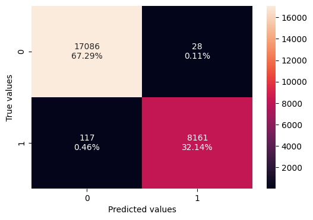

```python
#metrics Evaluation on train dataset
dt_perf_train=metrics_evaluation(model,X_train,y_train)
print(dt_perf_train)
#confusion matrix on train dataset
confusion_mat(model,X_train,y_train)
```

```
   accuracy    recall  f1_Score  precision
0   0.86557  0.804269  0.798624   0.793056
```

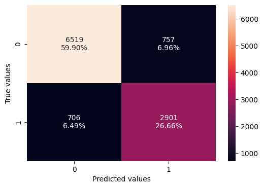

```python
#metrics evaluation on test dataset
dt_perf_test=metrics_evaluation(model,X_test,y_test)
print(dt_perf_test)
#confusion matrix on test data
confusion_mat(model,X_test,y_test)
```

observations:The model performs very well on the training dataset, but its performance significantly degrades on the test dataset, indicating overfitting.

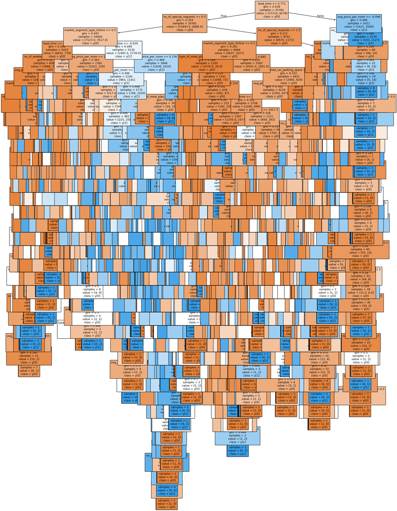

```python
#visualising the Decision tree
from sklearn import tree
feature_names=list(X.columns)
plt.figure(figsize=(20,30))
dt=tree.plot_tree(model,feature_names=feature_names,filled=True,fontsize=9,node_ids=False,class_names=True)
plt.show()
```

observations:Above Decision tree is very complex and with metrics projected there chances of overfitting, so its important to prune.

```python
#checking the significant features
print(pd.DataFrame(model.feature_importances_,columns=['Top 5 Significant features'],index=X.columns).sort_values(by='Top 5 Significant features',ascending=False).head(5))
```

```
                            Top 5 Significant features
lead_time                                     0.344718
avg_price_per_room                            0.182490
market_segment_type_Online                    0.095845
arrival_date                                  0.078257
no_of_special_requests                        0.070999
```

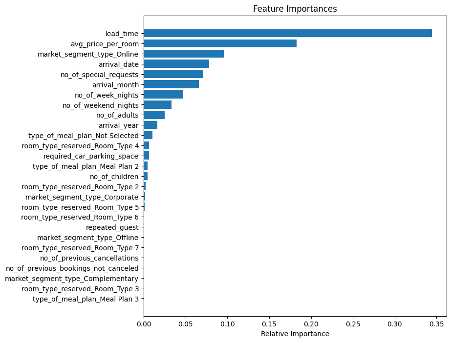

```python
importances = model.feature_importances_
indices = np.argsort(importances)

plt.figure(figsize=(8, 8))
plt.title("Feature Importances")
plt.barh(range(len(indices)), importances[indices], align="center")
plt.yticks(range(len(indices)), [feature_names[i] for i in indices])
plt.xlabel("Relative Importance")
plt.show()
```

observations: .The feauture importances that are in the top 3 are: lead_time avg_price_per_room market_segment_type_online .Also there are many features that are insignificant like room type 3,type of meal plan 3 .Pruning this unnecessary may reduce the complexity and yield to better accuracy.

Pruning the Model

```python
#using GridSerachCV for hyperParameter tuning
from sklearn.metrics import make_scorer
from sklearn.model_selection import GridSearchCV
model1=DecisionTreeClassifier(random_state=42)
parameters = {'max_depth': np.arange(1,10),
              'min_samples_leaf': [1, 2, 5, 7, 10,15,20],
              'max_leaf_nodes' : [2, 3, 5, 10],
              'min_impurity_decrease': [0.001,0.01,0.1]
             }
# Type of scoring used to compare parameter combinations
f1_scorer = make_scorer(f1_score)

# Type of scoring used to compare parameter combinations
gs=GridSearchCV(model1,parameters,scoring=f1_scorer,cv=5)

#fit the model
gs.fit(X_train,y_train)

# Output the best parameters and score
print("Best Parameters:", gs.best_params_)
print("Best Cross-Validation Score:", gs.best_score_)
```

[output not shown]

```python
#fitting the data to best-estimator
model1=gs.best_estimator_
model1.fit(X_train,y_train)
```

```
DecisionTreeClassifier(max_depth=np.int64(5), max_leaf_nodes=10,
                       min_impurity_decrease=0.001, random_state=42)
```

```
   accuracy   recall  f1_Score  precision
0  0.823921  0.68978  0.718646   0.750033
```

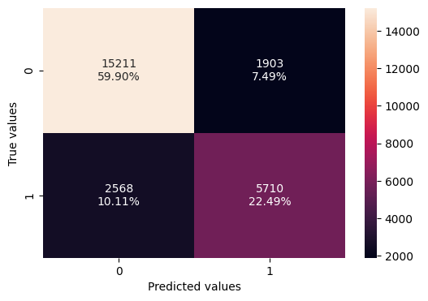

```python
#metrics evalutaion on training data
dt_tune_perf_train=metrics_evaluation(model1,X_train,y_train)
print(dt_tune_perf_train)
#confusion matrix report of training data
confusion_mat(model1,X_train,y_train)
```

```
   accuracy    recall  f1_Score  precision
0   0.82808  0.683671  0.724974   0.771589
```

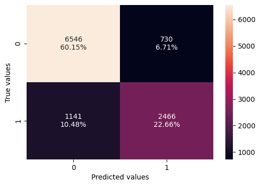

```python
#metrics evalutaion on testing data
dt_tune_perf_test=metrics_evaluation(model1,X_test,y_test)
print(dt_tune_perf_test)
#confusion matrix report of training data
confusion_mat(model1,X_test,y_test)
```

observations: .The metrics of training data set and testing data are similar,thus model is not overfitting. .The accuracy is 82% which is good fit. .The F1-score is the harmonic mean of precision and recall. With a score of 72.50%, the model is balancing precision and recall reasonably well. .The accuracy before pruning is 86 and f1_score is 80 before pruning ,after pruning it has decreased significantly.

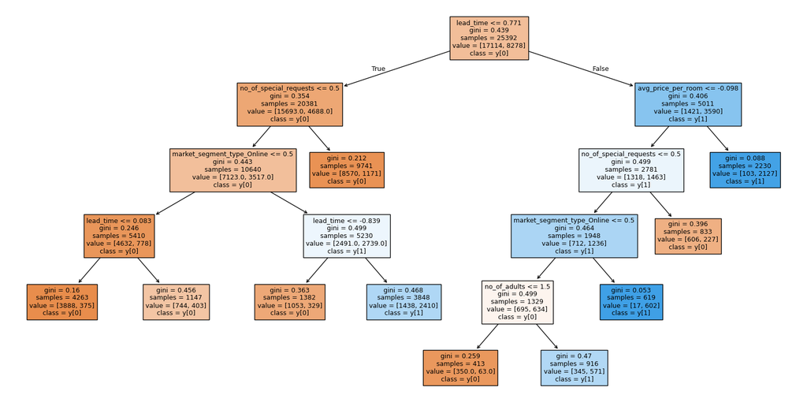

```python
#visualising the Decision tree
from sklearn import tree
feature_names=list(X.columns)
plt.figure(figsize=(20,10))
dt=tree.plot_tree(model1,feature_names=feature_names,filled=True,fontsize=9,node_ids=False,class_names=True)
```

```python
#checking the significant features
print(pd.DataFrame(model1.feature_importances_,columns=['Top 5 Significant features'],index=X.columns).sort_values(by='Top 5 Significant features',ascending=False).head(5))
```

```
                            Top 5 Significant features
lead_time                                     0.519839
market_segment_type_Online                    0.217042
no_of_special_requests                        0.134208
avg_price_per_room                            0.100818
no_of_adults                                  0.028095
```

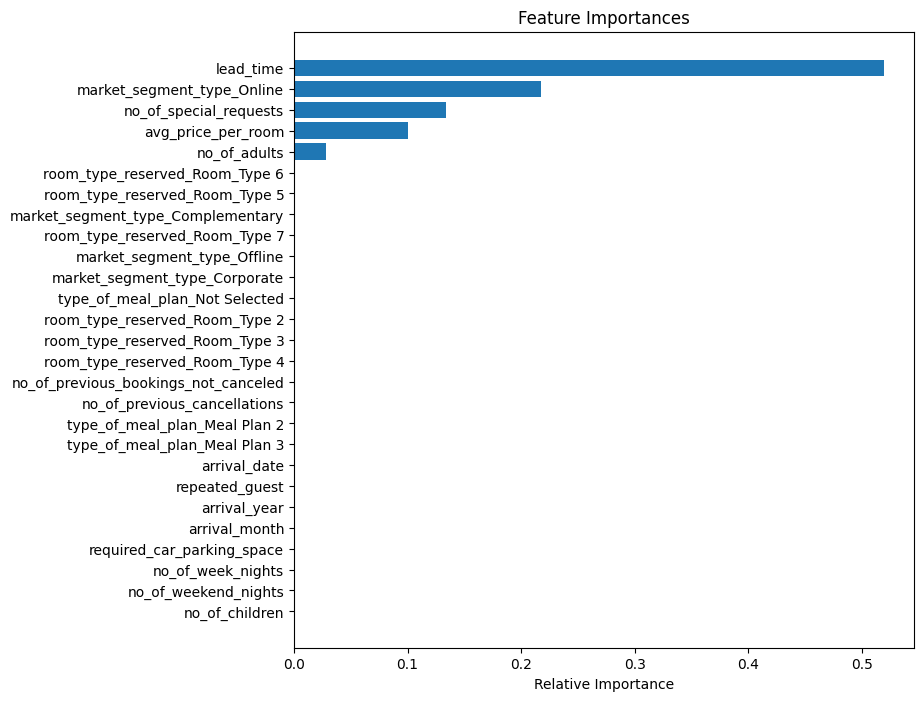

```python
importances = model1.feature_importances_
indices = np.argsort(importances)

plt.figure(figsize=(8, 8))
plt.title("Feature Importances")
plt.barh(range(len(indices)), importances[indices], align="center")
plt.yticks(range(len(indices)), [feature_names[i] for i in indices])
plt.xlabel("Relative Importance")
plt.show()
```

observations: .The significant features are changed compared to before pruning .The top 5 significant features are: lead_time market_segment_type_Online no_of_special_requests avg_price_per_room no_of_adults